# Analysis of Heart Disease Data

## **What is Heart Disease?**

Heart disease can represent any underlying issue regarding the cardiovascular system. This can include coronary artery disease, congenital heart defects, arrhythmia, and heart failiure. Heart disease is the leading cause of deaths in the United States. According to the CDC (Centers for Disease Control and Prevention), approximately 659,000 people in the United States die from heart disease each year - that is 1 in every 4 deaths. To put this in perspective, 1 person dies from heart disease every 36 seconds! Many factors are believed to be the cause for heart disease including lifestyle, stress levels, and genetics. Thus, it can be easily seen that this is an essential topic for us as a nation to investigate/study, as any progress can save thousands if not millions of lives.

## **Motivation**

As we can see above heart disease is clearly not something to be taken lightly. What are the measures we can take to prevent it? What can we do to save more lives? The WHO (World Health Organization) states that it is important to detect cardiovascular disease as early as possible so that management with counselling and medicines can begin. Many patients die because their symptoms go unnoticed or because they aren't tested for heart disease. This is exactly where data science can come into play. We can use data science to analyze the many factors that are plausibly correlated to heart disease. This in a sense, will give us insights as to whether it is possible to create a predictive model deciding whether a patient has heart disease based on their individual characteristics (in particular, the factors correlated to heart disease). By accomplishing this we will be able to predict whether any given person has heart disease based on their underyling symptoms/characteristics, this in turn can lead to quick detection + treatment and save lives!

## **Libraries**

```python
import numpy as np
import pandas as pd
import re
import matplotlib.pyplot as plt
from sklearn import linear_model
from sklearn.impute import KNNImputer
from sklearn.ensemble import RandomForestClassifier
from sklearn.linear_model import LinearRegression
from sklearn import preprocessing
import statsmodels.formula.api as smf
from IPython.display import Image
import requests
import numpy as np
import pandas as pd
import matplotlib.pyplot as plt
import seaborn as sns
from matplotlib.pyplot import figure
from matplotlib import pyplot
from PIL import Image
import statsmodels.api as sm
import statsmodels.formula.api as smf
from sklearn.neighbors import KNeighborsClassifier
from sklearn.model_selection import train_test_split
from sklearn.model_selection import cross_val_score
from sklearn.ensemble import RandomForestClassifier
import warnings
warnings.filterwarnings('ignore')
from sklearn.model_selection import GridSearchCV
from sklearn.metrics import classification_report
from sklearn.tree import DecisionTreeClassifier
from sklearn.metrics import accuracy_score

#pd.set_option('display.max_rows', None)
```

## **Data Collection**

This heart disease data comes from the UCI (University of California, Irvine) Machine Learning Repository. You can access the dataset link **[here](https://archive.ics.uci.edu/ml/datasets/heart+disease)**. The dataset itself was compiled by researchers from multiple hospitals and originally had 76 features. The observations were patients who had come to the hospital with unusual heart issues. Their corresponding features in the dataset are their recorded properties/characteristics. The dataset we have downloaded will only have the major 14 features, as it is only required we focus on these to get strong predictions and analysis (as the other features have been studied to have lesser effects on the probability of causing heart disease). For further information on why these 14 features are the most tightly related factors to heart disease read Mayo Clinic's article on heart disease **[here](https://www.mayoclinic.org/diseases-conditions/heart-disease/symptoms-causes/syc-20353118)**. Now we will take a closer look at the attributes. What are they? What values do they take on? How are they related to heart disease? These questions are answered in the data set description (also available in the UCI repository) which you can access **[here](https://archive.ics.uci.edu/ml/machine-learning-databases/heart-disease/heart-disease.names)**.

Attribute information:

(1) age: recorded age of observed patient.

(2) sex: recorded sex of observed patient. 1 is male 0 is female.

(4) trestbps: Resting blood pressure (in mm Hg on admission to the hospital). Obviously, the higher the more severe and negative effects the blood pressure level can have on health, in particular, the heart.

(5) chol: serum cholestoral in mg/dl. The higher the more negative effects that it can have.

(6) fbs: (fasting blood sugar > 120 mg/dl) (1 = true; 0 = false)

(7) restecg: resting electrocardiographic results. The results take on the following values and correspond to the following properties of the patient: 0 -> normal, 1 -> having ST-T wave abnormality (T wave inversions and/or ST elevation or depression of > 0.05 mV), and 2 -> showing probable or definite left ventricular hypertrophy by Estes' criteria. Again, as above values correspond to progressively worser states.

(8) thalach: maximum heart rate achieved

(9) exang: exercise induced angina (1 = yes; 0 = no)

(10) oldpeak = ST depression induced by exercise relative to rest

(11) slope: the slope of the peak exercise ST segment. The follows values correspond to the slope types: 1 -> unsloping, 2 -> flat, and 3 -> downsloping

(12) ca: number of major vessels (0-3) colored by flourosopy

(13) thal: 3 = normal; 6 = fixed defect; 7 = reversable defect

(14) target: whether the patient in question has heart disease (represented by 1) or not (takes on value of 0)

```python
heart_data = pd.read_csv("heart_disease_data.csv", header=None)

heart_data
```

|  | 0 | 1 | 2 | 3 | 4 | 5 | 6 | 7 | 8 | 9 | 10 | 11 | 12 | 13 |
| --- | --- | --- | --- | --- | --- | --- | --- | --- | --- | --- | --- | --- | --- | --- |
| 0 | 63 | 1 | 1 | 145 | 233 | 1 | 2 | 150 | 0 | 2.3 | 3 | 0.0 | 6.0 | 0 |
| 1 | 67 | 1 | 4 | 160 | 286 | 0 | 2 | 108 | 1 | 1.5 | 2 | 3.0 | 3.0 | 2 |
| 2 | 67 | 1 | 4 | 120 | 229 | 0 | 2 | 129 | 1 | 2.6 | 2 | 2.0 | 7.0 | 1 |
| 3 | 37 | 1 | 3 | 130 | 250 | 0 | 0 | 187 | 0 | 3.5 | 3 | 0.0 | 3.0 | 0 |
| 4 | 41 | 0 | 2 | 130 | 204 | 0 | 2 | 172 | 0 | 1.4 | 1 | 0.0 | 3.0 | 0 |
| ... | ... | ... | ... | ... | ... | ... | ... | ... | ... | ... | ... | ... | ... | ... |
| 298 | 45 | 1 | 1 | 110 | 264 | 0 | 0 | 132 | 0 | 1.2 | 2 | 0.0 | 7.0 | 1 |
| 299 | 68 | 1 | 4 | 144 | 193 | 1 | 0 | 141 | 0 | 3.4 | 2 | 2.0 | 7.0 | 2 |
| 300 | 57 | 1 | 4 | 130 | 131 | 0 | 0 | 115 | 1 | 1.2 | 2 | 1.0 | 7.0 | 3 |
| 301 | 57 | 0 | 2 | 130 | 236 | 0 | 2 | 174 | 0 | 0.0 | 2 | 1.0 | 3.0 | 1 |
| 302 | 38 | 1 | 3 | 138 | 175 | 0 | 0 | 173 | 0 | 0.0 | 1 | NaN | 3.0 | 0 |

303 rows × 14 columns

## **Cleaning Data**

Now that we have our overall data, let us do some cleaning and make the dataset in shape for our exploratory data analysis. This is important in guaranteeing good results and our ability to utilize certain machine learning models + facilities. That is, we must meet certain prerequisites on our data looks like (i.e. numbers should usually be floats, missing values should be absent or imputed on, etc). Also, we should probably name + reformat our dataset so it is easy for us to understand and digest information on first glance!

```python
# setting column names
heart_data.columns = ['age', 'sex', 'cp', 'trestbps', 'chol',
              'fbs', 'restecg', 'thalach', 'exang',
              'oldpeak', 'slope', 'ca', 'thal', 'target']

heart_data
```

|  | age | sex | cp | trestbps | chol | fbs | restecg | thalach | exang | oldpeak | slope | ca | thal | target |
| --- | --- | --- | --- | --- | --- | --- | --- | --- | --- | --- | --- | --- | --- | --- |
| 0 | 63 | 1 | 1 | 145 | 233 | 1 | 2 | 150 | 0 | 2.3 | 3 | 0.0 | 6.0 | 0 |
| 1 | 67 | 1 | 4 | 160 | 286 | 0 | 2 | 108 | 1 | 1.5 | 2 | 3.0 | 3.0 | 2 |
| 2 | 67 | 1 | 4 | 120 | 229 | 0 | 2 | 129 | 1 | 2.6 | 2 | 2.0 | 7.0 | 1 |
| 3 | 37 | 1 | 3 | 130 | 250 | 0 | 0 | 187 | 0 | 3.5 | 3 | 0.0 | 3.0 | 0 |
| 4 | 41 | 0 | 2 | 130 | 204 | 0 | 2 | 172 | 0 | 1.4 | 1 | 0.0 | 3.0 | 0 |
| ... | ... | ... | ... | ... | ... | ... | ... | ... | ... | ... | ... | ... | ... | ... |
| 298 | 45 | 1 | 1 | 110 | 264 | 0 | 0 | 132 | 0 | 1.2 | 2 | 0.0 | 7.0 | 1 |
| 299 | 68 | 1 | 4 | 144 | 193 | 1 | 0 | 141 | 0 | 3.4 | 2 | 2.0 | 7.0 | 2 |
| 300 | 57 | 1 | 4 | 130 | 131 | 0 | 0 | 115 | 1 | 1.2 | 2 | 1.0 | 7.0 | 3 |
| 301 | 57 | 0 | 2 | 130 | 236 | 0 | 2 | 174 | 0 | 0.0 | 2 | 1.0 | 3.0 | 1 |
| 302 | 38 | 1 | 3 | 138 | 175 | 0 | 0 | 173 | 0 | 0.0 | 1 | NaN | 3.0 | 0 |

303 rows × 14 columns

```python
# checking if there are any missing values, the following command will give us missing value information
# regarding every features (column)
heart_data.isnull().sum()
```

```
age         0
sex         0
cp          0
trestbps    0
chol        0
fbs         0
restecg     0
thalach     0
exang       0
oldpeak     0
slope       0
ca          4
thal        2
target      0
dtype: int64
```

Since we have missing values (namely, in the feature sets of "ca" and "thal") we must figure out a way to counteract this. An obvious would be to totally disaccount for these observations (therefore, deleting these patients from our dataset) and continuing our analysis on the remaining. But, it is important to note that we already only have around 303 patients, thus, even deleting 6 observations would correspond to a 2% decrease in our dataset (which isn't bad, but we could do better). Thus, we will choose the method of mean imputation (another option would be to do hot-deck or cold-deck imputation - imputing based on neighboring observations).

```python
# note, we could use the sklearn functionality SingleImputer(), but we will implement the imputation
# function ourselves here. We will not need to round the average to nearest integer as both "ca" and "thal"
# are stored in the dataframe as float64 datatypes!


# we begin by doing mean imputation for the "ca" field missing values

ca_sum = 0
ca_count = 0

# calculation of the mean
for i, row in heart_data.iterrows():
    if(np.isnan(row['ca']) == False):
        ca_sum += row['ca']
        ca_count += 1

ca_mean = ca_sum / ca_count

print(ca_mean)

# imputing the mean now
for i in range(0, len(heart_data)):
    if(np.isnan(heart_data.at[i, 'ca'] )):
        heart_data.at[i, 'ca']  = ca_mean


# we do the same calculations + imputations for the "thal" field missing values now!

thal_sum = 0
thal_count = 0

for i, row in heart_data.iterrows():
    if(np.isnan(row['thal']) == False):
        thal_sum += row['thal']
        thal_count += 1

thal_mean = thal_sum / thal_count

print(thal_mean)

for i in range(0, len(heart_data)):
    if(np.isnan(heart_data.at[i, 'thal'])):
        heart_data.at[i, 'thal'] = thal_mean


# makesure that what we did worked out!
# if it did we should have no more null values!
heart_data.isnull().sum()
```

```
0.6722408026755853
4.73421926910299
```

```
age         0
sex         0
cp          0
trestbps    0
chol        0
fbs         0
restecg     0
thalach     0
exang       0
oldpeak     0
slope       0
ca          0
thal        0
target      0
dtype: int64
```

```python
# checking datatypes to get an idea of what we're dealing with!
heart_data.dtypes
```

```
age           int64
sex           int64
cp            int64
trestbps      int64
chol          int64
fbs           int64
restecg       int64
thalach       int64
exang         int64
oldpeak     float64
slope         int64
ca          float64
thal        float64
target        int64
dtype: object
```

Now, we are onto the last step of cleaning our data. Notice, that our motivation in this analysis is to at the end possibly be able to predict accurately whether a patient has heart disease or not. We don't necessarily care how much of the disease is inherently present within the patient themselves. Thus, we can eliminate the 0-4 scale in favour of the 0-1 scale (which we've assumed we will be using as described in the data collection stage). This is trival to accomplish as 1-4 (there is some level of heart disease) represent presence which is denoted by 1, and 0 will represent absence.

```python
# examine what values the target takes on & check how many of each target value exist
print(heart_data['target'].value_counts())

# beginning shifting process
for i in range(0, len(heart_data)):
    if(heart_data.at[i, 'target'] > 0):
        heart_data.at[i, 'target']  = 1
```

```
0    164
1     55
2     36
3     35
4     13
Name: target, dtype: int64
```

```python
# let's double check after the shift!
print(heart_data['target'].value_counts())
```

```
0    164
1    139
Name: target, dtype: int64
```

## **Exploratory Data Analysis**

Now that our dataset is tidy, we can begin the next step of the datascience pipeline - exploratory data analysis. Our ultimate goal for the overall project (in regard to the motivation we discussed at the beginning sections) is to be able to create some sort of model that can efficiently predict whether a patient has heart disease or not based on their inherent characteristics (feature set). We will first analyze direct correlations between heart disease cases and specific attributes, then we as we shall see we will compare attributes to other attributes and see if there are any relations there as well (i.e. this can be useful in combining attributes, eliminating them, creating new metrics, etc).

Firstly, let's check if the observations have skewed counts of occurrences of the target field. That is, do too many of the patients have heart disease while the number who don't is negligent? If this is the case it can take a severe impact on our analysis as we won't have a complete picture of the dataset to define correlations!

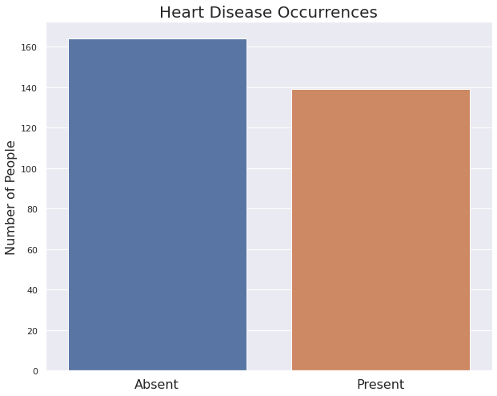

```python
fig = plt.figure(figsize = (10, 8))

ax = sns.countplot(x = 'target', data = heart_data)
plt.title("Heart Disease Occurrences", size = 20)
ax.set_xticklabels(['Absent', 'Present'], fontsize=16)

plt.xlabel('', fontsize = 16)
plt.ylabel('Number of People', fontsize = 16);
```

Roughly, the numbers are equal (164 vs 139). Thus, one categorical type doesn't make up too much of the data leading to a skewed analysis. We shall continue with confidence! Let's now begin finding correlations between heart disease and some of the recorded features in our observations. Looking through our feature list we shall begin by focusing on chest pain, resting blood pressure, exercised induced angina, fasting blood sugar, maximum heart rate achieved, and cholestoral levels.

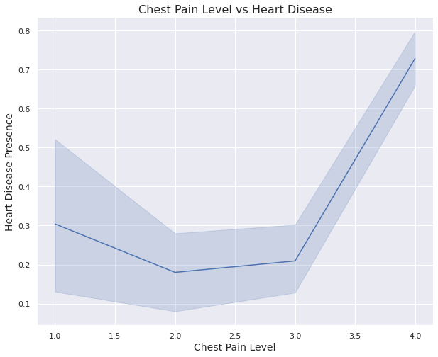

```python
fig = plt.figure(figsize = (10, 8))
sns.lineplot(x='cp', y='target', data=heart_data)
pyplot.ylabel('Heart Disease Presence', size = 14)
pyplot.xlabel('Chest Pain Level', size = 14)
pyplot.title("Chest Pain Level vs Heart Disease", size = 16)
```

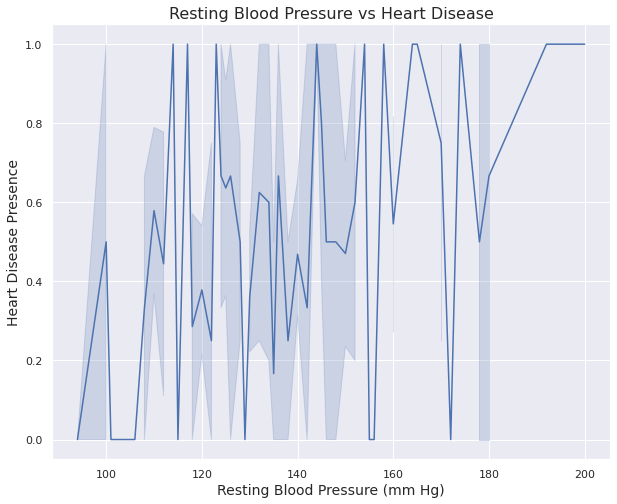

```python
fig = plt.figure(figsize = (10, 8))
sns.lineplot(x='trestbps', y='target', data=heart_data)
pyplot.ylabel('Heart Disease Presence', size = 14)
pyplot.xlabel('Resting Blood Pressure (mm Hg)', size = 14)
pyplot.title("Resting Blood Pressure vs Heart Disease", size = 16)
```

Well, clearly there is a lot of noise present, and we can't really tell whether there is a strict correlation. However, if we look closely we see that there is an increase in the mean location of where the lines are located. That is, it is apparent (disregarding the noise) that resting blood pressure is actually leading to an increase in the chance of heart disease presence. Since, there is a lot of noise, our intuition based on first glance may be incorrect. Let us further clarify our reasoning by plotting distributions of resting blood pressure based on presence of heart disease or not. If we are correct, we should see that the center of the distribution of blood pressure with respect to heart disease presence should be greater than its partner!

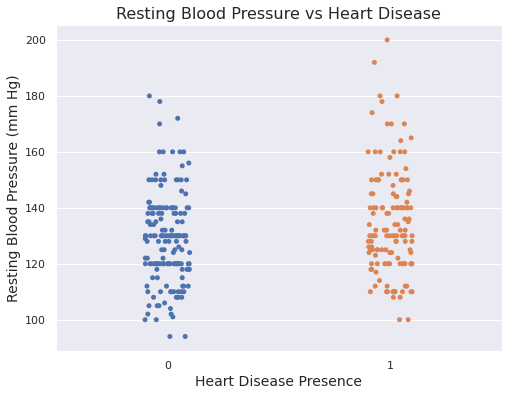

```python
f, ax = plt.subplots(figsize=(8, 6))
sns.stripplot(x="target", y="trestbps", data=heart_data)
pyplot.title("Resting Blood Pressure vs Heart Disease", size = 16)
pyplot.ylabel('Resting Blood Pressure (mm Hg)', size = 14)
pyplot.xlabel('Heart Disease Presence', size = 14)
plt.show()
```

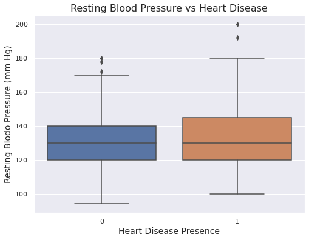

```python
f, ax = plt.subplots(figsize=(8, 6))
sns.boxplot(x="target", y="trestbps", data=heart_data)
pyplot.title("Resting Blood Pressure vs Heart Disease", size = 16)
pyplot.ylabel('Resting Blodo Pressure (mm Hg)', size = 14)
pyplot.xlabel('Heart Disease Presence', size = 14)
plt.show()
```

Overall, we see that our assumption about the data distribution was correct. There does seem to be an upper skew and incline in heart disease presence as the resting blood pressure increases. This means we are going in the right direction with our analysis as this is scientifically true as well, and you can refer **[here](https://utswmed.org/medblog/high-blood-pressure-heart-disease/)** to learn more!

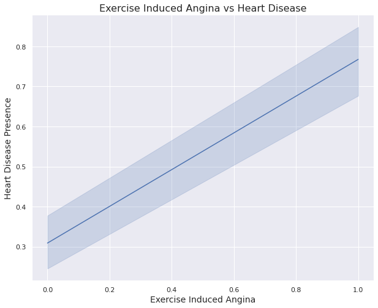

```python
fig = plt.figure(figsize = (10, 8))
sns.lineplot(x='exang', y='target', data=heart_data)
pyplot.ylabel('Heart Disease Presence', size = 14)
pyplot.xlabel('Exercise Induced Angina', size = 14)
pyplot.title("Exercise Induced Angina vs Heart Disease", size = 16)
```

Wow! There seems to be a clear cut (seemingly perfect linear) trend between exercise induced angina and heart disease presence. We will take note of this when building our model in the future. Maybe we can weight this feature as more important in the modelling as it is clearly has strong correlation with the presence of heart disease!

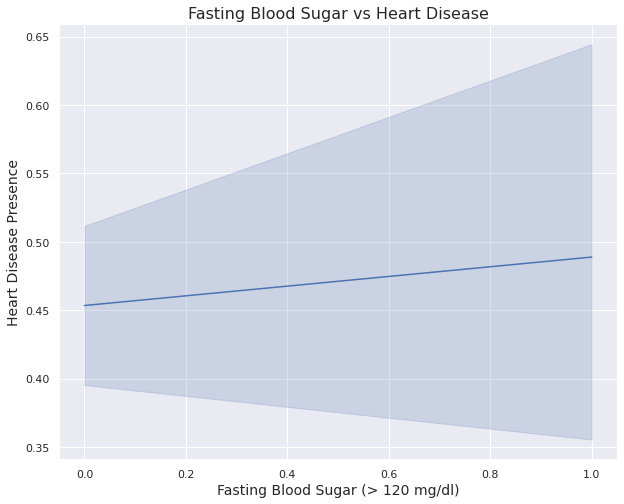

```python
fig = plt.figure(figsize = (10, 8))
sns.lineplot(x='fbs', y='target', data=heart_data)
pyplot.ylabel('Heart Disease Presence', size = 14)
pyplot.xlabel('Fasting Blood Sugar (> 120 mg/dl)', size = 14)
pyplot.title("Fasting Blood Sugar vs Heart Disease", size = 16)
```

Fasting blood sugar does have a slight trend with heart disease presence, although it is neglibible. We will have to see later on with other methods (i.e. heatmap, etc) if there is any sort of overall significance that this feature bears in the bigger picture!

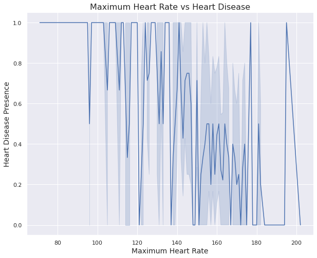

```python
fig = plt.figure(figsize = (10, 8))
sns.lineplot(x='thalach', y='target', data=heart_data)
pyplot.ylabel('Heart Disease Presence', size = 14)
pyplot.xlabel('Maximum Heart Rate', size = 14)
pyplot.title("Maximum Heart Rate vs Heart Disease", size = 16)
```

This seems a bit contradictory to what is expected. Inuitively it is expected that heart disease and heart attacks are a result of very high maximum heart rate, but our data clearly shows otherwise. This calls for a bit more extensive analysis into maximum heart rate vs heart disease presence. We will use a similar approach to what we did with resting blood pressure levels. That is, we will first do a strip plot and then a box plot to look at the distributions of maximum heart rate corresponding to whether heart disease was present or not.

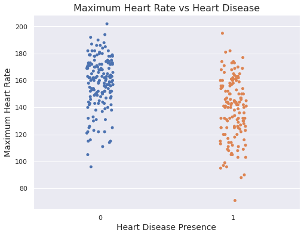

```python
f, ax = plt.subplots(figsize=(8, 6))
sns.stripplot(x="target", y="thalach", data=heart_data)
pyplot.title("Maximum Heart Rate vs Heart Disease", size = 16)
pyplot.ylabel('Maximum Heart Rate', size = 14)
pyplot.xlabel('Heart Disease Presence', size = 14)
plt.show()
```

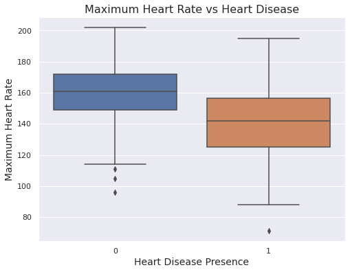

```python
f, ax = plt.subplots(figsize=(8, 6))
sns.boxplot(x="target", y="thalach", data=heart_data)
pyplot.title("Maximum Heart Rate vs Heart Disease", size = 16)
pyplot.ylabel('Maximum Heart Rate', size = 14)
pyplot.xlabel('Heart Disease Presence', size = 14)
plt.show()
```

Again, we have similar results! Obviously, we can blame this logical disrepancy on data collection methods or just pure chance. However, after doing some further research, a Harvard paper actually says that low heart rate can actually correlate to higher chances of heart disease. The article can be found **[here](https://www.health.harvard.edu/heart-health/hows-your-heart-rate-and-why-it-matters)**. So this can explain away what we are witnessing.

Now, before we wrap up the exploratory data analysis and continue onto creating a predictive model, we should probably tackle two more things: attribute vs attribute connections and whether sex/age have an impact on predicting heart disease. Let's begin by checking for attribute vs attribute connetions (as mentioned before this can lead to adding new metrics, eliminating attributes, combining them, etc).

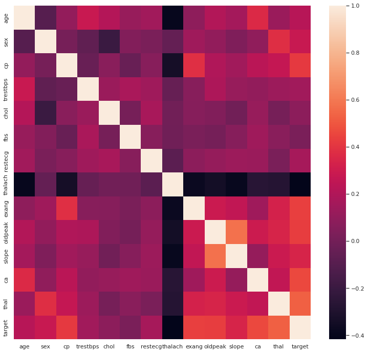

```python
# display a heatmap so we can easily notice feature to feature correlations!

corr = heart_data.corr()

cmap = cmap=sns.diverging_palette(5, 250, as_cmap=True)

# this is for an interactive heatmap
def magnify():
    return [dict(selector="th",
                 props=[("font-size", "7pt")]),
            dict(selector="td",
                 props=[('padding', "0em 0em")]),
            dict(selector="th:hover",
                 props=[("font-size", "12pt")]),
            dict(selector="tr:hover td:hover",
                 props=[('max-width', '200px'),
                        ('font-size', '12pt')])
]

corr.style.background_gradient(cmap, axis=1)\
    .set_properties(**{'max-width': '80px', 'font-size': '10pt'})\
    .set_caption("Hover to magify")\
    .set_precision(2)\
    .set_table_styles(magnify())

# plot the heatmap
f, ax = plt.subplots(figsize=(13, 12))
sns.heatmap(corr,
        xticklabels=corr.columns,
        yticklabels=corr.columns)
```

The single correlation that sticks out more than all others is that between the following two features: slope and oldpeak. This makes sense as both features are dealing with the ST depression and peak, thus, in they are the inverse values of each other (creating a correlation!). This means that in certain models, it would be fine to totally leave out one of them for the other (a sort of substitution). This may provide better accuracy and lessen noise. We will just look at the correlation a bit more indepth by plotting slope and oldpeak together and see what results we get.

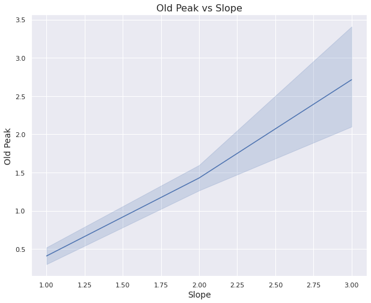

```python
fig = plt.figure(figsize = (10, 8))
sns.lineplot(x='slope', y='oldpeak', data=heart_data)
pyplot.ylabel('Old Peak', size = 14)
pyplot.xlabel('Slope', size = 14)
pyplot.title("Old Peak vs Slope", size = 16)
```

Right on! Our evaluation from the heatmap proved to be fruitful. Again, logically speaking this was expected though as by definition the old peak and slope are approximately talking about the inverses of one another (i.e. the high and low of peaks induced by exercise). You can read more about this approximate implicit relation between old peak and slope **[here](https://www.ijrte.org/wp-content/uploads/papers/v8i2S3/B11630782S319.pdf)**.

Now tackle our last question: does age or sex have an impact on deciding whether a given patient has heart disease or not? Since our data comes from a random sample, we will do a binning into categories and see whether a certain category (or range in the case of age) has signficantly higher cases of positive heart disease. We will begin by analyzing the impact of sex.

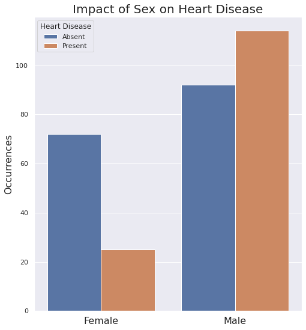

```python
sns.set_theme(style="darkgrid")
sns.set(rc = {'figure.figsize':(8,9)})

ax = sns.countplot(x="sex", hue="target", data=heart_data)

# setting labels, title, and legend names
ax.set_xticklabels(['Female', 'Male'], fontsize=16)
ax.set_xlabel("", fontsize = 16)
ax.set_ylabel("Occurrences", fontsize = 16)
plt.legend(title='Heart Disease', loc='upper left', labels=['Absent', 'Present'])
ax.set_title("Impact of Sex on Heart Disease", fontsize=20)
```

Lastly, we will check whether there is some sort of relationship between age and heart disease. We will do this simply by grouping into major age groups (20 years per group) and check whether one group has much more occurrences of positive heart disease cases. This will tell us that there is some sort of relationship between age and chance of heart disease (remember that this does not imply causation, just merely a relationship/correlation).

```
[0, 4, 82, 53, 0]
```

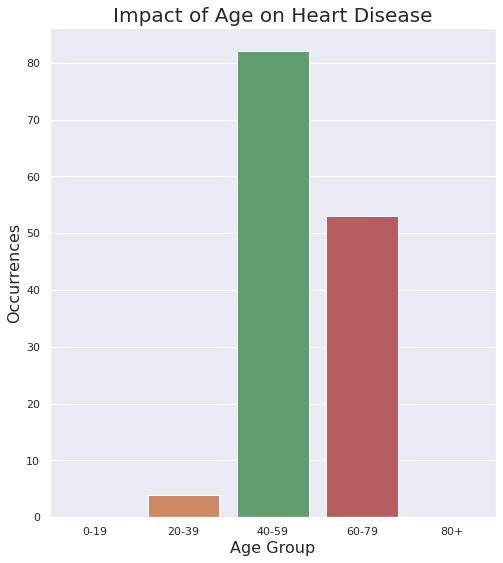

```python
age_group = [0, 0, 0, 0, 0]

# counting sizes for each age group
for i in range(len(heart_data)):
    if(heart_data.at[i, 'age'] < 20): # ages 0 - 19
        age_group[0] += heart_data.at[i, 'target']
    elif(heart_data.at[i, 'age'] < 40): # ages 20 - 39
        age_group[1] += heart_data.at[i, 'target']
    elif(heart_data.at[i, 'age'] < 60): # ages 40 - 59
        age_group[2] += heart_data.at[i, 'target']
    elif(heart_data.at[i, 'age'] < 80): # ages 60 - 79
        age_group[3] += heart_data.at[i, 'target']
    else: # ages 80+
        age_group[4] += heart_data.at[i, 'target']

print(age_group)

sns.set_theme(style="darkgrid")
sns.set(rc = {'figure.figsize':(8,9)})

# we are actually creating the bar plot now!
ax = sns.barplot(y=age_group, x=['0-19', '20-39', '40-59', '60-79', '80+'])

# setting labels, title, and legend names
#ax.set_xticklabels(['0-19', '20-39', '40-59', '60-79', '80+'], fontsize=16)
ax.set_xlabel("Age Group", fontsize = 16)
ax.set_ylabel("Occurrences", fontsize = 16)
ax.set_title("Impact of Age on Heart Disease", fontsize=20)
```

From, the bar plot above we see that people in the age group of 40-59 years seem to be the most prone to having heart disease. If we were being extra careful in our analysis + modelling we could take this into account (i.e. split up models based on age, introduced a new varaible that focuses more on age, etc). Also, like many times before in this investigation, this finding does seem to bear resemblance to actual researched findings. It actually has been proven that ageshave similar proportions of overall heart disease cases. The only difference between our collected data and reality is that more people are actually prone when they are in the ages 60-79 rather than 40-59. The article at heart.org perfectly depicts this (click **[here](https://www.heart.org/idc/groups/heart-public/@wcm/@sop/@smd/documents/downloadable/ucm_483970.pdf)**).

## **Model Building & Predictions**

We've come to the last step in our analysis and do what we promised at the beginning - predict heart disease based on a patients inherent characteristics. In order to accomplish this we must first build a machine learning model. As part of our model selection process we will play around with the following models to see which one works best: Decision Trees, Support Vector Machines (SVM), Logistic Regression, and lastly K-Nearest Neighbors. We will also tune each models respective hyperparameters (this is also an essential component of model selection!) in order to get optimal results and maximize accuracy!

Before we get into training the models, it is necessary that we first create a training set which we will build the models on, and also a testing set which we will assess the ability/precision that our model possesses. Lot of these tasks are taken care of by the vast utilities provided by libraries such as Scikit-learn!

```python
y = heart_data['target']
x = heart_data.drop(['target'], axis=1)

# splitting our data into testing and training data (we use 1-4 split for test-train respectively)
x_train, x_test, y_train, y_test = train_test_split(x, y, test_size=0.2, random_state=42)
```

We begin by training a Decision Tree model. We do hyperparameter tuning as well with the parameters below. For the hyperparameter tuning we will use GridSearchCV which will find optimal parameters by running 10-fold cross validation (this is an inbuilt facility that Scikit-learn provides us with)

```python
# Decision Tree Model

# we are testing the hyperparameters so we first define them
tree = DecisionTreeClassifier()
parameters = {'max_depth':[2,4,6,8,10,12], 'min_samples_leaf':[3,6,9,12,15]}

# grid search will optimize the parameters for us, this is done using 10-fold cross validation technique
tree_clf = GridSearchCV(tree, parameters, scoring='accuracy', cv=10, return_train_score=False,verbose=1)
tree_clf.fit(x_train, y_train)

print(tree_clf.best_params_) # let's see what the best parameters really were!

y_true, y_pred = y_test, tree_clf.predict(x_test)

# calculating accuracy using its basic definition
accuracy = accuracy_score(y_test, y_pred)
print('Accuracy: %.3f' % (accuracy * 100))
```

```
Fitting 10 folds for each of 30 candidates, totalling 300 fits
{'max_depth': 8, 'min_samples_leaf': 9}
Accuracy: 85.246
```

We have an 85.246% accuracy which isn't bad at all. But obviously, in the real-world our model will need much more finetuning and we would need to up the accuracy to atleast 99% to use it in practice. This can be achieved in 2 major ways: one would be to increase the sample sizes so our models are built on more data and therefore are virtually stronger, the second would be to try out more hyperparameters and tune to even better optimized parameters! Next, we will try out logistic regression. Here we will just train the model using Scikit-learn's inbuilt logistic regression functionality. We will test it using cross_val_score which will give us the mean accuracy of the 10-fold cross validation.

```python
# Logistic Regression Model

model = linear_model.LogisticRegression()
accuracy = cross_val_score(model, x_test, y_test, scoring='accuracy', cv = 10)
print(accuracy.mean())
```

```
0.8547619047619047
```

We improved the overall acurracy a little bit from the Decision Tree. Now we have 85.477% which is a bit of an improvement. However, we should try to aim higher. We will try support vector machines (SVM) next!

```python
# Support Vector Machine

svm_clf = SVC(kernel='rbf', gamma=0.1, C=1.0)
svm_clf.fit(x_train, y_train)

accuracy = cross_val_score(svm_model, x_test, y_test, scoring='accuracy', cv=5)
print(accuracy.mean())
```

[output not shown]

Now, we will train one last model: the K-Nearest Neighbors model. For this one we will do hyperparameter tuning using GridSearchCV to get the optimal parameters (similar to what we did for the Decision Tree Classifiers).

```python
knn = KNeighborsClassifier()
from sklearn.model_selection import GridSearchCV
k_range = list(range(31))
param_grid = dict(n_neighbors=k_range)

grid = GridSearchCV(knn, param_grid, cv=10, scoring='accuracy', return_train_score=False,verbose=1)

grid_search=grid.fit(x, y)
print(grid_search.best_params_)
```

```
Fitting 10 folds for each of 31 candidates, totalling 310 fits
{'n_neighbors': 24}
```

```python
knn = KNeighborsClassifier(n_neighbors=24)

accuracy = cross_val_score(knn, x, y, cv=10, scoring='accuracy')

print(accuracy.mean())
```

```
0.6835483870967741
```

K-Nearest Neighbor seemingly performs the worst out of the 4 models. But at 70% predictive ability it is not good enough in practice. This may because we didn't normalize the weights of the different features. That is, one feature may had much more impact on the heart disease decision than the others (even if it was the lesser important feature). We could fix this by going back to our original data collection and normalizing the data such that every feature has equal weighting. This would make calculations regarding euclidean distance (i.e. even other distance metrics) give better accuracies (when used in model computations)!

## **Conclusion**

We began by collecting the dataset from the UCI (University of California, Irvine) Machine Learning Repository. We first had to clean the data (fix missing value - which we imputed with the mean of the respective column. Then we began to explore and play around with the data (the exploratory data analysis stage of our investigation). We found correlations between various features and the target we aimed to predict (whether a given patient was positive for heart disease or not). At the same time however, we also found correlations between features and features (if we were doing a more complex routine for model building + analysis this would be useful in eliminating, combining, and augmenting two or more features to create new stronger predictive features. Lastly, we built a total of 4 models on top of the given data using techniques such as 10-fold cross validation and hyperparameter tuning. We garnered up to 86% accuracy. We conclude that although we were able to get a pretty strong accuracy (~86%) this isn't enough in practice as we should aim for 99%+ accuracy in a situation of determining whether a patient has heart disease or not (this is for ethical and practical purposes). As we mentioned, this could be fixed if we were given more training data to build our models on and had if we had more computational power to try out all possible hyperparameters (atleast reasonable ones). Overall, what we have done is just the basics and there can be much more analysis + model building done. Heart disease is a growing problem in the United States, and it must be tackled immediately to save lives in the future. Data science will be a major part is solving this problem. Utilizing its predictive abilities and analysis to find correlations we will not only be able to predict when a patient has heart disease and save their lives, but we will also be able to determine the various factors that lead to heart disease (i.e. in the context of datascience we call this feature correlation)! Thank you for following along.

## **Further Resources**

Throughout this reading we have provided further reading in the form of interactive buttons (denoted by the blue "here"). You can click on these to learn more about the sections in which they are located. Below is a summary of some of the major resources that we used to make this investigation possible. (NOTE: the below links are NOT the ones used in the interactive buttons, to find more about them, go click them!)

(1) **https://www.cdc.gov/heartdisease/index.htm#:~:text=Heart%20disease%20is%20the%20leading,can%20lead%20to%20heart%20attack.**

(2) **https://www.mayoclinic.org/diseases-conditions/heart-disease/symptoms-causes/syc-20353118**

(3) **https://towardsdatascience.com/predicting-presence-of-heart-diseases-using-machine-learning-36f00f3edb2c**

(4) **https://scikit-learn.org/stable/tutorial/basic/tutorial.html**

(5) **https://www.mygreatlearning.com/blog/gridsearchcv/**

(6) **https://www.svhhearthealth.com.au/conditions/coronary-artery-disease**

(7) **https://www.pennmedicine.org/for-patients-and-visitors/patient-information/conditions-treated-a-to-z/heart-failure**